# Data Programming

Project - Netflix Dataset

Author

Mirko Dugajlic

Published

June 11, 2024

## Introduction

### About

Netflix stands as a leading force in the realm of media and video streaming. With a staggering array of over 8,000 movies and TV shows accessible on their platform, as of mid-2021, their global subscriber count exceeds 200 million. This tabulated dataset comprehensively catalogues all offerings on Netflix, including vital details such as cast, directors, ratings, release year, duration, and more.

### Why this topic?

- Firstly, it provides a rich source of information about user preferences and viewing habits, which are essential for building accurate recommendation models.
- Secondly, the Netflix movies dataset enables the development and evaluation of advanced *recommendation algorithms* and *machine learning models*. With access to detailed information about movie genres, ratings, release years, crew and cast, and user interactions, etc. scientists can experiment with various algorithms such as collaborative filtering, content-based filtering, and hybrid methods to improve the accuracy and relevance of recommendations.

Moreover, by continually updating and expanding the dataset, we contribute to the ongoing research and development efforts in the field of recommendation systems. As streaming platforms like Netflix evolve and introduce new content, it becomes imperative to adapt recommendation algorithms to accommodate these changes and ensure that users receive personalized and engaging recommendations.

## Dataset Overview

### About

The Netflix Titles dataset is a comprehensive compilation of movies and TV shows available on Netflix, covering various aspects such as the title type, director, cast, country of production, release year, rating, duration, genres (listed in), and a brief description. This dataset is instrumental for analyzing trends in Netflix content, understanding genre popularity, and examining the distribution of content across different regions and time periods.

### Key Details

**Dataset**: [Netflix Dataset](https://www.kaggle.com/datasets/rahulvyasm/netflix-movies-and-tv-shows)

**Total Entries**: The dataset contains 8,809 entries, each representing a unique movie or TV show.

**Columns**: There are 12 columns in the dataset:

1. **show_id**: A unique identifier for each title.
2. **type**: The category of the title, which is either ‘Movie’ or ‘TV Show’.
3. **title**: The name of the movie or TV show.
4. **director**: The director(s) of the movie or TV show. (Contains null values for some entries, especially TV shows where this information might not be applicable.)
5. **cast**: The list of main actors/actresses in the title. (Some entries might not have this information.)
6. **country**: The country or countries where the movie or TV show was produced.
7. **date_added**: The date the title was added to Netflix.
8. **release_year**: The year the movie or TV show was originally released.
9. **rating**: The age rating of the title.
10. **duration**: The duration of the title, in minutes for movies and seasons for TV shows.
11. **listed_in**: The genres the title falls under.
12. **description**: A brief summary of the title.

## Analysis

### Frequently used functions and libraries

```r
library(readxl)
library(tibble)
library(dplyr)
library(tidyverse)
library(ggplot2)

# get counts for any passed column

get.count <- function(data, column) {
  column <- enquo(column)  # Capture the column name
  cnt <- data %>%
    count(!!column)  # Unquote the column name
  return(cnt)
}

custom_colors <- c("Movie" = "#db0000", "TV Show" = "#564d4d")
```

### Visual representation of dataset

```r
df <- read.csv("./files/netflix_titles.csv")
columns_to_delete <- grep("^X", names(df))
# Reason for deleting columns is that it makes additional columns after reading files.
# Columns are called X, X.1, X.2 and so on.
df <- df[, -columns_to_delete]
as_tibble(df)
```

```
# A tibble: 8,809 × 12
   show_id type    title   director cast  country date_added release_year rating
   <chr>   <chr>   <chr>   <chr>    <chr> <chr>   <chr>             <int> <chr>
 1 s1      Movie   Dick J… "Kirste… ""    "Unite… September…         2020 PG-13
 2 s2      TV Show Blood … ""       "Ama… "South… September…         2021 TV-MA
 3 s3      TV Show Gangla… "Julien… "Sam… ""      September…         2021 TV-MA
 4 s4      TV Show Jailbi… ""       ""    ""      September…         2021 TV-MA
 5 s5      TV Show Kota F… ""       "May… "India" September…         2021 TV-MA
 6 s6      TV Show Midnig… "Mike F… "Kat… ""      September…         2021 TV-MA
 7 s7      Movie   My Lit… "Robert… "Van… ""      September…         2021 PG
 8 s8      Movie   Sankofa "Haile … "Kof… "Unite… September…         1993 TV-MA
 9 s9      TV Show The Gr… "Andy D… "Mel… "Unite… September…         2021 TV-14
10 s10     Movie   The St… "Theodo… "Mel… "Unite… September…         2021 PG-13
# ℹ 8,799 more rows
# ℹ 3 more variables: duration <chr>, listed_in <chr>, description <chr>
```

### Error checking

$$\begin{equation}
RMSE = \sqrt{\sum_{i=1}^{n} \frac{(\hat y_i - y_i)^2} {n}}
\end{equation}$$
Here we can see how to calculate RMSE (Root Mean Square) which is either one of two closely related and frequently used measures of the differences between true or predicted values on the one hand and observed values or an estimator on the other. Variables used in the formula are:

- $\hat{y}$ - predicted values
- $y$ - observed values
- $n$ - number of observations

### Movie & TV Show distribution

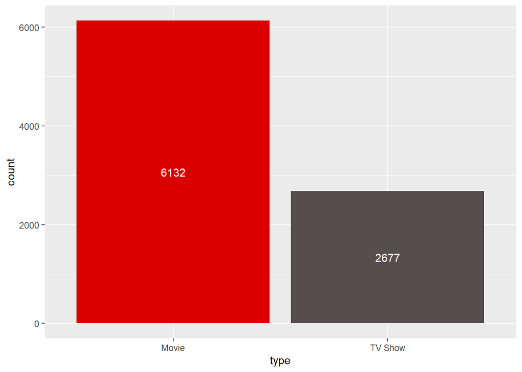

Figure 1: Movie & TV Shows total count

```r
ggplot(df, aes(x = type, fill = type)) +
  geom_bar() +
  geom_text(stat='count', aes(label=..count..), position=position_stack(vjust=0.5), color="white") +
  theme(legend.position = "none") +
  scale_fill_manual(values = custom_colors)
```

On this graph we can see that the movies are leading and that is somehow logical because they are easier to make.

The data from Figure 1 could be also presented as percentages from the whole dataset.

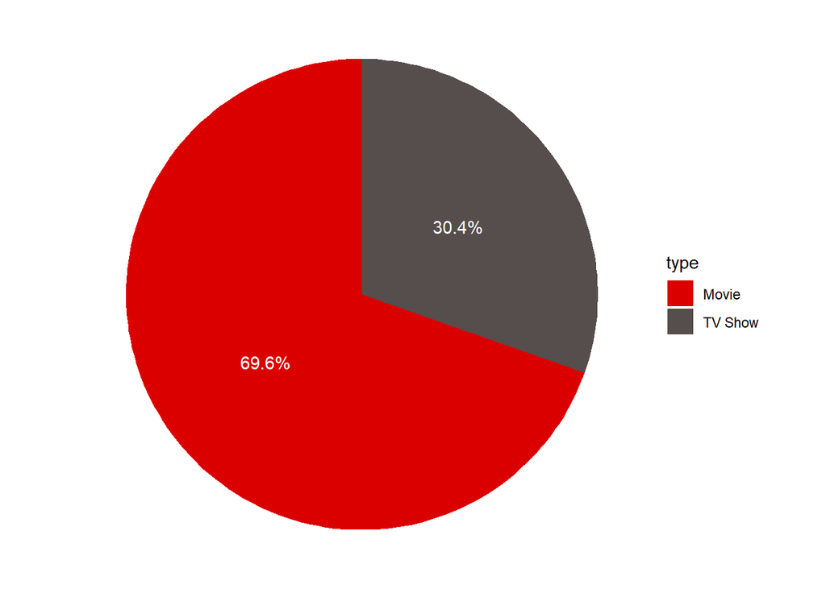

```r
df_summary <- df %>%
  count(type) %>%
  mutate(percentage = round(n / sum(n) * 100, 1))

ggplot(df_summary, aes(x = "", y = n, fill = type)) +
  geom_bar(stat = "identity", width = 1) +
  coord_polar(theta = "y") +
  geom_text(aes(label = paste0(percentage, "%")),
            position = position_stack(vjust = 0.5), color = "white") +
  theme_void()+
  scale_fill_manual(values = custom_colors)
```

### Distribution over countries

After these two (Figure 1 and Figure 2) basic overviews lets dive into the distribution of movies and TV shows over countries.

In the next figures Table 1 and Figure 3 we will show the percentage and the total number of the movies and tv shows made per country.

```r
# handling 'NA' values but in this dataset it is empty string
df <- df %>%
  mutate(country = ifelse(country == "", "Unknown", country))

# some movies/shows have more countries
df_split <- df %>%
  separate_rows(country, sep = ", ")

df_country_data = get.count(df_split,country) %>%
                  arrange(desc(n))
total_countries = sum(df_country_data$n)

df_country_data <- df_country_data %>%
  mutate(perc = round((n / total_countries) * 100, 1))

# Get first 15 rows
df_country_data_display <- head(df_country_data, n = 15)

df_country_data_display <- df_country_data_display %>%
  rownames_to_column(var = "Position")

# Display top 15 countries as a table
knitr::kable(df_country_data_display[, c("Position","country", "n", "perc")],
      col.names = c("#","Country","Total (movies+shows)", "% of total"))
```

Table 1: Top 15 countries with movies + TV-shows count

| # | Country | Total (movies+shows) | % of total |
| --- | --- | --- | --- |
| 1 | United States | 3690 | 34.0 |
| 2 | India | 1046 | 9.6 |
| 3 | Unknown | 831 | 7.7 |
| 4 | United Kingdom | 804 | 7.4 |
| 5 | Canada | 445 | 4.1 |
| 6 | France | 393 | 3.6 |
| 7 | Japan | 318 | 2.9 |
| 8 | South Korea | 232 | 2.1 |
| 9 | Spain | 232 | 2.1 |
| 10 | Germany | 226 | 2.1 |
| 11 | Mexico | 169 | 1.6 |
| 12 | China | 162 | 1.5 |
| 13 | Australia | 160 | 1.5 |
| 14 | Egypt | 117 | 1.1 |
| 15 | Turkey | 113 | 1.0 |

In the Table 1 we can see that the leading countries, especially USA, both have the most famous and the biggest movie and TV show production cities. For more information about differences between Hollywood and Bollywood [click here](https://testbook.com/key-differences/difference-between-bollywood-and-hollywood).

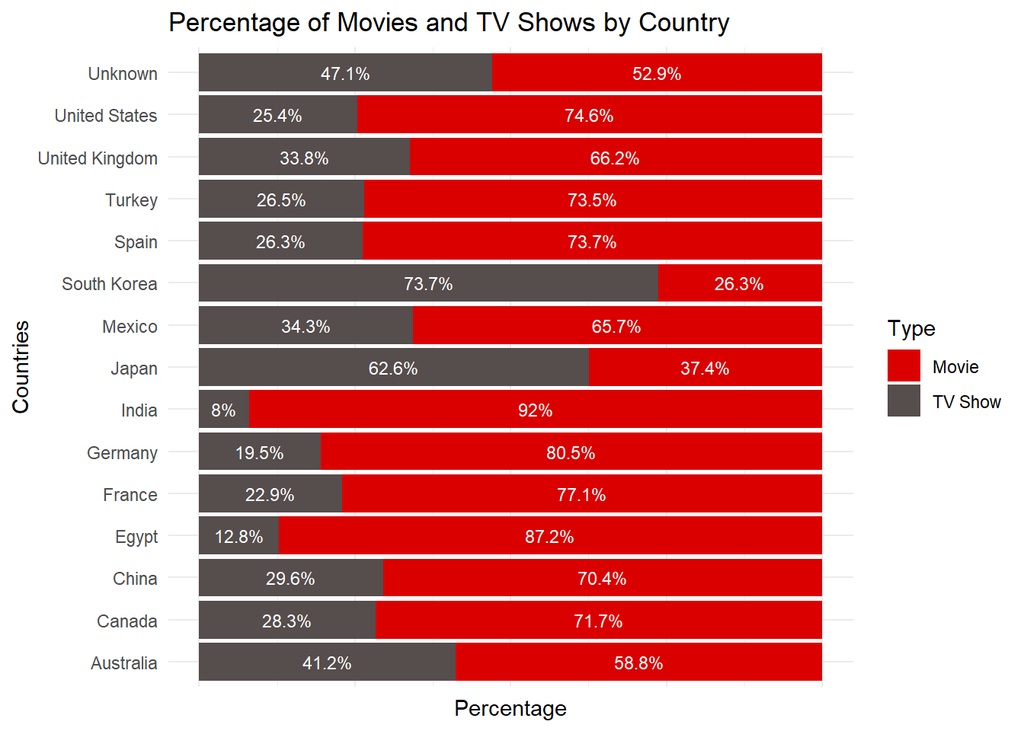

Figure 3: Movie & TV Shows distribution over countries in %

```r
df_to_display <- df_split %>%
  semi_join(df_country_data_display, by = "country") %>%
  group_by(country) %>%
  count(type)


df_to_display <- df_to_display %>%
  group_by(country) %>%
  mutate(total = sum(n))

df_to_display <- df_to_display %>%
  group_by(country) %>%
  mutate(perc = round((n/total *100),1))


ggplot(df_to_display, aes(fill=type, x=perc, y=country)) +
  geom_bar(position="fill", stat="identity") +
  geom_text(aes(label = paste0(perc, "%")), position = position_fill(vjust = 0.5), color = "white", size = 3) +
  labs(title = "Percentage of Movies and TV Shows by Country",
       x = "Percentage",
       y = "Countries",
       fill = "Type") +
  scale_fill_manual(values = custom_colors) +
  theme_minimal() +
  theme(axis.text.x = element_blank(),  # Remove x-axis labels
        axis.ticks.x = element_blank())  # Remove x-axis ticks
```

### Movies and TV Shows average duration over years

```r
# make a plot with years on x axis and number of movies for decades


# Change to numeric value
df$year <- as.numeric(df$release_year) # Extract the year

# Duration extraction
df$duration_num <- as.numeric(str_extract(df$duration, "\\d+"))
df_groupedby_type <- df %>%
  group_by(.$type)


# Filter out the Movies and group by year
df_movies <- df %>%
  filter(type == "Movie") %>%
  group_by(year)

df_shows <- df %>%
  filter(type == "TV Show") %>%
  group_by(year)

# Calculate the average duration of movies and series per year
df_avg_movie_duration <- df_movies %>%
  summarise(avg_duration = mean(duration_num, na.rm = TRUE))

df_avg_series_duration <- df_shows %>%
  summarise(avg_duration = mean(duration_num, na.rm = TRUE))
```

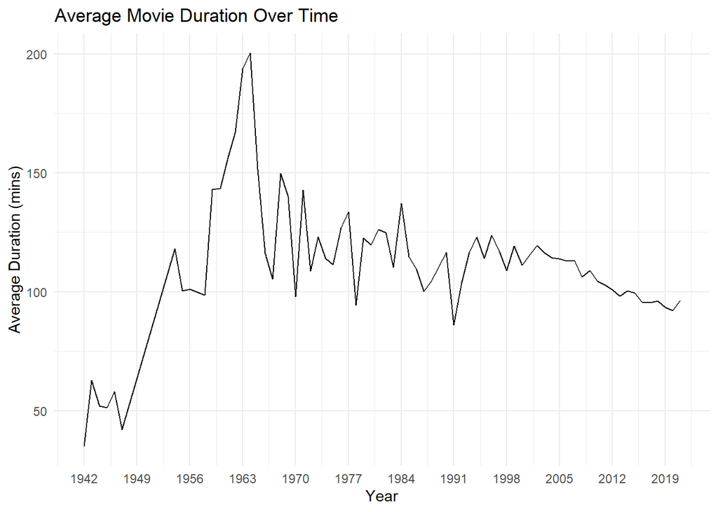

Figure 4: Movies

```r
# Create the plot fot movies
ggplot(df_avg_movie_duration, aes(x=year, y=avg_duration)) +
  geom_line() +
  scale_x_continuous(breaks = seq(min(df_avg_movie_duration$year), max(df_avg_movie_duration$year), by = 7)) +
  labs(x="Year", y="Average Duration (mins)", title="Average Movie Duration Over Time") +
  theme_minimal()
```

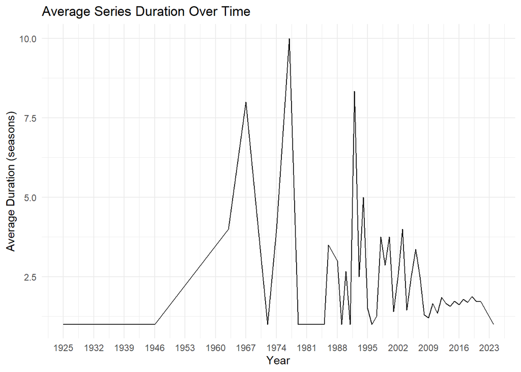

Figure 5: TV Show

```r
# Create the plot for series
ggplot(df_avg_series_duration, aes(x=year, y=avg_duration)) +
  geom_line() +
  scale_x_continuous(breaks = seq(min(df_avg_series_duration$year), max(df_avg_series_duration$year), by = 7)) +
  labs(x="Year", y="Average Duration (seasons)", title="Average Series Duration Over Time") +
  theme_minimal()
```

#### Discussion

Figure 4 depicts how the average duration of movies (in minutes) has expanded dramatically in period between 1942 until around1965. From there, the length of each movie varies between 100 and 150 minutes. In the previous 20 years, there has been a tiny but consistent drop in duration.

Figure 5 does not show anything specific, but it does demonstrate how the duration represented in seasons is not a useful way to express the length of TV shows, if it is the only one.

### Top 5

Table 2: Longest movies and their genres

| Title | Genres | Length |
| --- | --- | --- |
| Black Mirror: Bandersnatch | Dramas, International, Sci-Fi & Fantasy | 312 min |
| Headspace: Unwind Your Mind | Documentaries | 273 min |
| The School of Mischief | Comedies, Dramas, International | 257 min |
| No Longer Kids | Comedies, Dramas, International | 237 min |
| Lock Your Girls | Comedies, International, Romantic | 233 min |

In Table 2 we can see top 5 longest movies from the dataset listed in descending order. On the other side in Table 3 we can see top 5 longest Tv Shows in terms of seasons.

```r
top_n_tvshows <- df %>%
  filter(type == "TV Show") %>%
  arrange(desc(duration_num))

# Get first 5 rows
top_n_tvshows <- head(top_n_tvshows, n = 5)

# Display top N movies as a table
knitr::kable(top_n_tvshows[, c("title", "listed_in", "duration")],
      col.names = c( "Title","Genre", "Duration"))
```

Table 3: Longest TV Shows and their genres

| Title | Genre | Duration |
| --- | --- | --- |
| Grey’s Anatomy | Romantic TV Shows, TV Dramas | 17 Seasons |
| Supernatural | Classic & Cult TV, TV Action & Adventure, TV Horror | 15 Seasons |
| NCIS | Crime TV Shows, TV Dramas, TV Mysteries | 15 Seasons |
| Heartland | TV Dramas | 13 Seasons |
| COMEDIANS of the world | Stand-Up Comedy & Talk Shows, TV Comedies | 13 Seasons |

## Conclusion and further research

In this project, we investigated a subset of possible analysis and visualizations for this dataset, concentrating especially on the distribution of movies and TV series among nations. However, there are countless more options for further investigation and study.

One area for future research could be the extraction and analysis of genres from the dataset. By categorizing movies and TV series based on genre, we may learn about audience preferences, trends over time, and how genre popularity varies across nations. Analyzing genre data in relation to criteria such as release year, production type (movies or series), and even audience ratings could reveal important insights into the entertainment industry’s dynamics.

Furthermore, we might investigate the dataset’s temporal characteristics by evaluating trend lines over time. This could include studying how the number of movies and TV episodes released each year has varied over time, finding trends in genre popularity across different time periods, and looking for any links between release dates and things like viewer ratings or box office results.

We might also look deeper into the behavior of different sorts of content (movies vs. series) and how it relates to measures like viewer engagement, audience demographics, and streaming platform preferences. Understanding how audience preferences differ between movies and television shows could help streaming platforms and production businesses improve their content creation and marketing tactics.

Overall, there are numerous potential directions for future analysis and exploration of this dataset, ranging from genre-based analyses to temporal trends and audience behavior. By leveraging advanced analytical techniques and visualization methods, we can uncover valuable insights into the dynamics of the entertainment industry and audience preferences.

## Books

One of the popular books and well-written ones is (Frey 2021). The content is about *algorithmic recommender systems*, deployed by media companies to suggest content based on users’ viewing histories, have inspired hopes for personalized, curated media but also dire warnings of filter bubbles and media homogeneity. All these facts were introduced in Section 1.

## Articles

- For more information about Netflix recommendations and recommender systems read (Chiny et al. 2022).
- Additional paper (Amatriain and Basilico 2015)

## References

Amatriain, Xavier, and Justin Basilico. 2015. “Recommender Systems in Industry: A Netflix Case Study.” In, 385–419. https://doi.org/10.1007/978-1-4899-7637-6_11.

Chiny, Mohamed, Marouane Chihab, Omar Bencharef, and Chihab Younes. 2022. “Netflix Recommendation System Based on TF-IDF and Cosine Similarity Algorithms.” In, 15–20. https://doi.org/10.5220/0010727500003101.

Frey, Mattias. 2021. *Algorithms, Film Choice, and the History of Taste*. Berkeley: University of California Press. https://doi.org/doi:10.1525/9780520382022.